# Assignment_4_jprillam

```r
#Setting the working directory
setwd("/Users/joe/Desktop/Masters Program/Fall 2026/Fundamentals of Machine Learning/Module 6/Assignment 4")

#Reading in the csv to create the original data frame
Pharma <- read.csv("Pharmaceuticals.csv")
```

```r
#installing/loading all of the packages needed for the assignment

library(dplyr)
library(factoextra)
```

```r
#standardize the 9 numerical variables we will use for clustering

vars <- c("Market_Cap", "Beta", "PE_Ratio", "ROE", "ROA", "Asset_Turnover", "Leverage", "Rev_Growth", "Net_Profit_Margin")

StdPharma <- Pharma %>%
  mutate(across(all_of(vars), ~ as.numeric(scale(.x))))
```

Things I know I need to do:

X standardize the numerical values in the dataset before clustering Done

_ determine the right weighting for different variables… How? IDK What some of these are… Coming back to this, I think I am over thinking it - Revenue growth seems particularly important, as does Market Cap.

_ determine the right kind of distance measure to use e.g., euclidean, manhattan, etc. This one I need to read more on… What exactly would cause me to choose a different measure?

```r
#Create table with only the 9 standardized variables for clustering
StdPharmaTrimmed <- StdPharma %>%
  select(Market_Cap, Beta, PE_Ratio, ROE, ROA, Asset_Turnover, Leverage, Rev_Growth, Net_Profit_Margin)
```

```r
#double checking whether there are many outliers int he data using the z score definition, just to make sure euclidean distance makes sense. I think manhattan would make sense were there a lot of outliers, but since there are few, I will stick with euclidean.
sapply(StdPharmaTrimmed, function(x) sum(abs(x) > 3, na.rm = TRUE))
```

```
       Market_Cap              Beta          PE_Ratio               ROE
                0                 0                 1                 0
              ROA    Asset_Turnover          Leverage        Rev_Growth
                0                 0                 1                 0
Net_Profit_Margin
                0
```

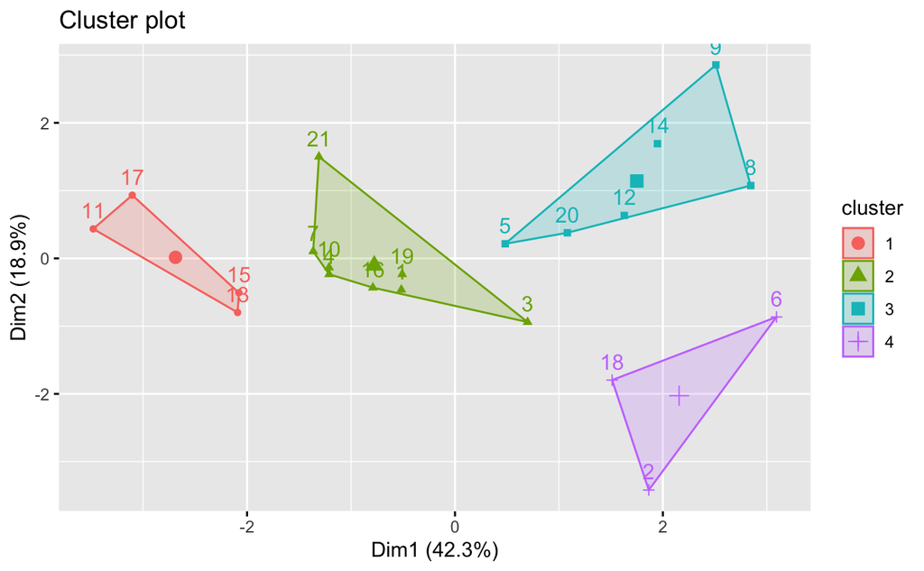

```r
#Clustering with 4 centroids
set.seed(404)

#might as well start 100 times since small df
k4 <- kmeans(StdPharmaTrimmed, centers = 4, nstart = 100)
fviz_cluster(k4, data = StdPharmaTrimmed)
```

```r
#Just taking an initial pass at clustering with no weights and 4 centroids
```

```r
#adding weights to variables that I'd anticipate and equities analyst might deem more important for investment decisions...
weights <- c(
  Market_Cap        = 1.5, #a clear way to differentiate size tier
  Rev_Growth        = 1.5, #clear growth signal
  Net_Profit_Margin = 1.5, #clear profit signal
  PE_Ratio          = 1.25, # valuation/expectations
  ROA               = 1,#keeping standard weight
  Leverage          = 1, #keeping standard
  Beta              = 0.75, # sector is defensive, so less discriminating on volitility
  ROE               = 0.75, # overlaps with ROA, margin, and leverage
  Asset_Turnover    = 1 # keep standard
)

# new dataframe with weights applied
StdPharmaWeighted <- sweep(StdPharmaTrimmed, 2, weights[names(StdPharmaTrimmed)], `*`)
```

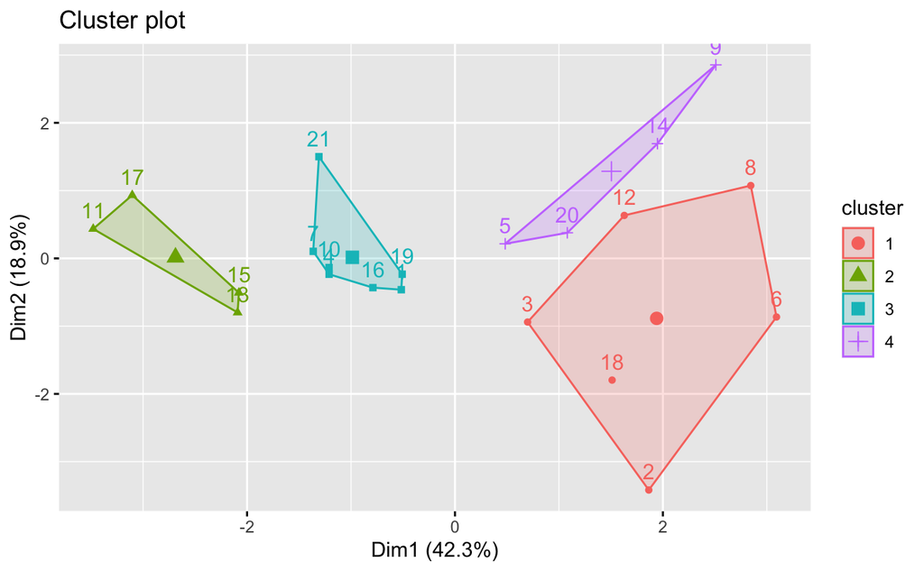

```r
#Clustering with 4 centers on weighted data
set.seed(404)

k4w <- kmeans(StdPharmaWeighted, centers = 4, nstart = 100)
fviz_cluster(k4w, data = StdPharmaWeighted)
```

```r
#cross tab to compare cluster assignments from equal weighting kmeans to the weighted kmeans.
table(equal = k4$cluster, weighted = k4w$cluster)
```

```
     weighted
equal 1 2 3 4
    1 0 4 0 0
    2 1 0 7 0
    3 2 0 0 4
    4 3 0 0 0
```

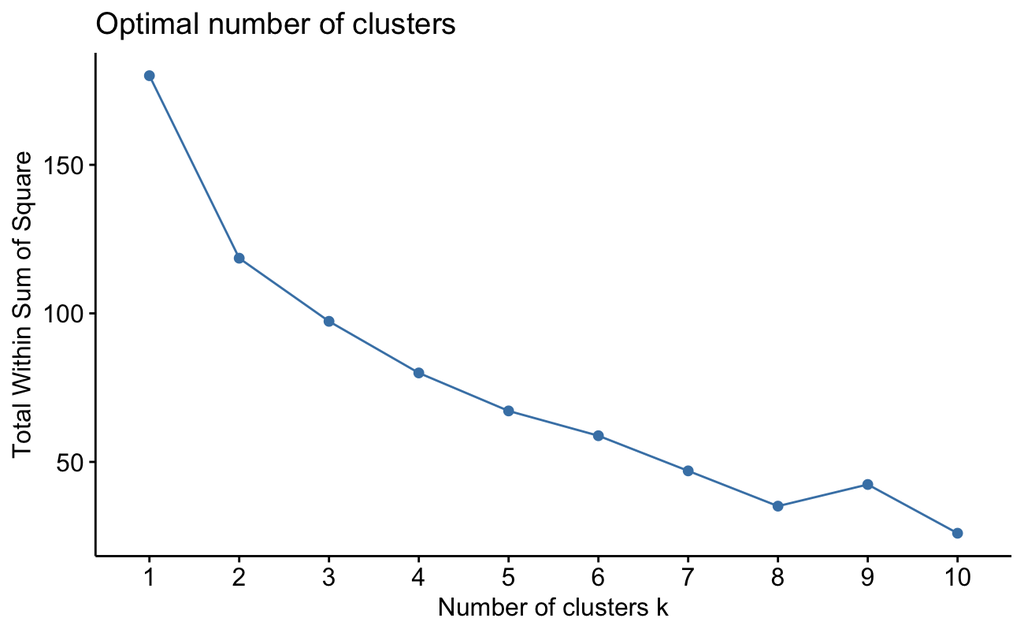

```r
#now going to start determining the right number of clusters for our data using the elbow method and the avg silhouette method. Also going to run this on weighted and unweighted data to see if I am changing the number of natural clusters in the data

set.seed(404)
#Visuals for un-weighted data
fviz_nbclust(StdPharmaTrimmed, kmeans, method = "wss")
```

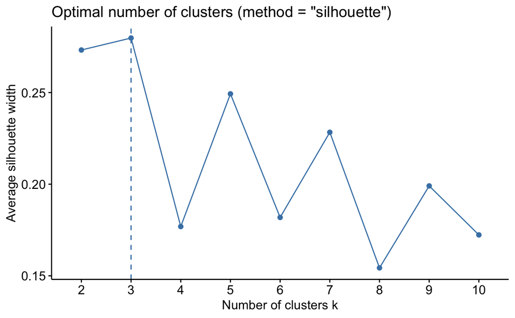

```r
fviz_nbclust(StdPharmaTrimmed, kmeans, method = "silhouette")
```

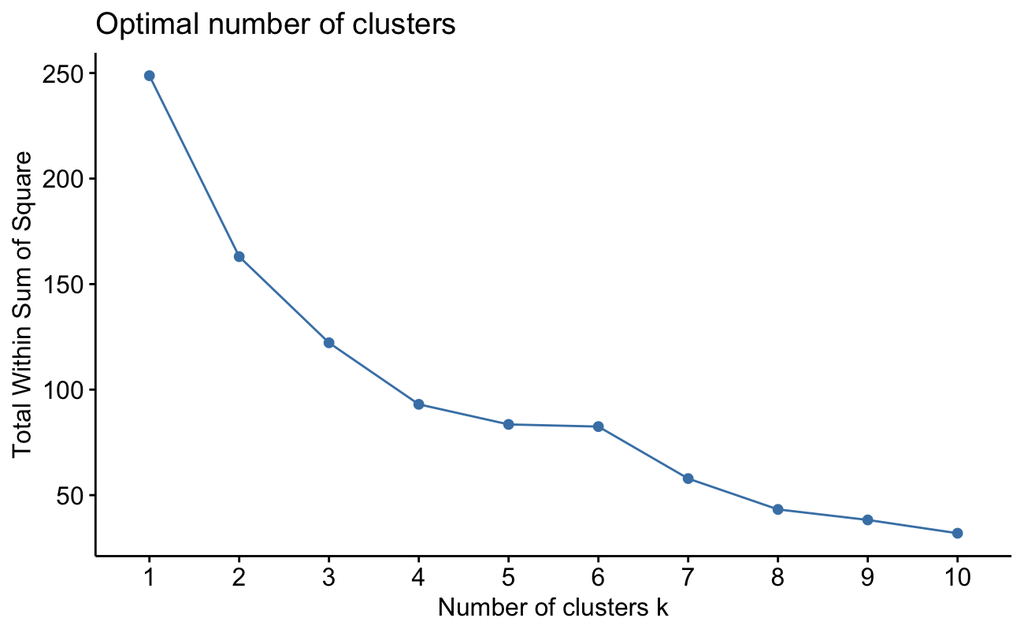

```r
#Visuals for weighted data

set.seed(404)
fviz_nbclust(StdPharmaWeighted, kmeans, method = "wss")
```

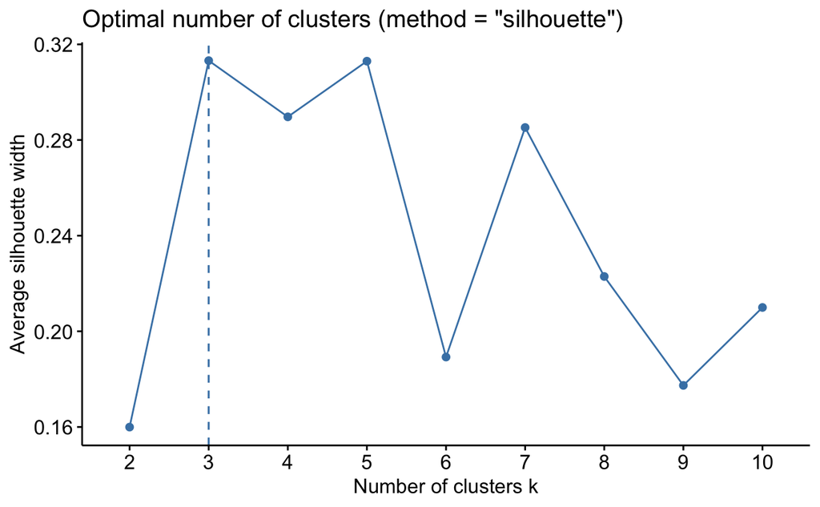

```r
fviz_nbclust(StdPharmaWeighted, kmeans, method = "silhouette")
```

```r
#Since I will run my clustering on the weighted data, I need to run the elbow and silhouette on this data. On the elbow chart, 4 seems to be the knee, describing that the benefit of increasing to 5 clusters is very little, and it doesn't do much to increase the similarity within clusters

#the silhouette seems to suggest that companies fit their clusters best with 3 or 5 clusters, but the trade off for 4 clusters is small...

#all in all, I am going with 4 clusters
```

```r
set.seed(404)
k4_final <- kmeans(StdPharmaWeighted, centers = 4, nstart = 100)

k4_final$size #checking the size of the clusters to make sure there are no super small clusters... Looks good. Retlatively even size.
```

```
[1] 6 4 7 4
```

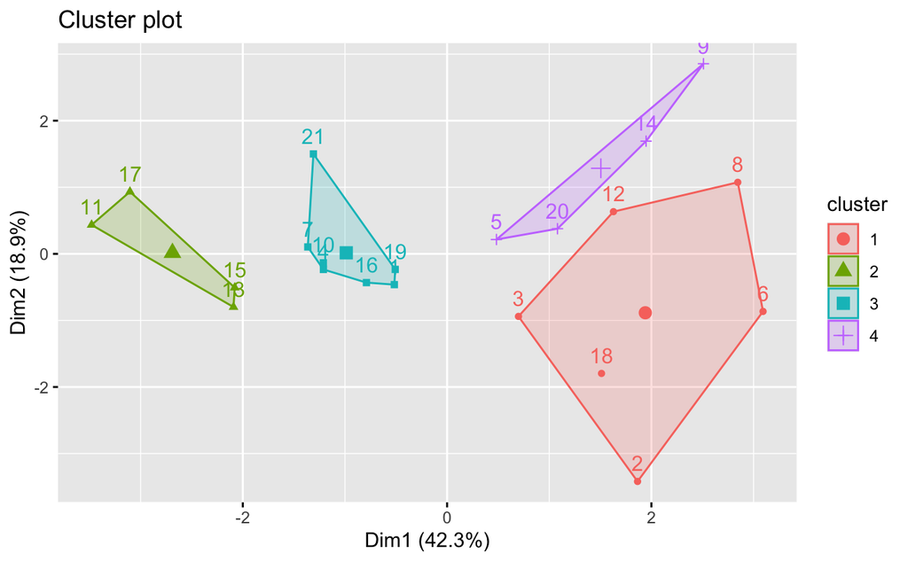

```r
fviz_cluster(k4_final, data = StdPharmaWeighted)
```

```r
StdPharma$cluster <-factor(k4_final$cluster)
```

```r
profile_z <- StdPharma %>%
  group_by(cluster) %>%
  summarise(n = n(), across(all_of(vars), mean), .groups = "drop")

profile_z %>% mutate(across(all_of(vars), ~ round(.x, 2)))
```

| cluster | n | Market_Cap | Beta | PE_Ratio | ROE | ROA | Asset_Turnover | Leverage | Rev_Growth | Net_Profit_Margin |
| --- | --- | --- | --- | --- | --- | --- | --- | --- | --- | --- |
| 1 | 6 | -0.73 | 0.47 | 0.82 | -0.71 | -0.99 | 0.00 | 0.57 | -0.48 | -1.25 |
| 2 | 4 | 1.70 | -0.18 | -0.20 | 1.23 | 1.35 | 1.15 | -0.47 | 0.47 | 0.59 |
| 3 | 7 | 0.09 | -0.46 | -0.32 | 0.33 | 0.54 | 0.07 | -0.26 | -0.72 | 0.73 |
| 4 | 4 | -0.76 | 0.28 | -0.48 | -0.74 | -0.81 | -1.27 | 0.06 | 1.52 | -0.01 |

```r
#Assigning cluster names in the dataframe

StdPharma <- StdPharma %>%
  mutate(cluster_name = recode(as.character(cluster),
    "1" = "Profit Challenged Small Caps",
    "2" = "Large Profit Leaders",
    "3" = "Mature Cash Cows",
    "4" = "High Growth Small Caps"
  ))
```

Assignment 4 Questions/Instructions Below

1. Use only the numerical variables (1 to 9) to cluster the 21 firms. Justify the various choices made in conducting the cluster analysis, such as weights for different variables, the specific clustering algorithm(s) used, the number of clusters formed, and so on.

Done - work shown above

2. Interpret the clusters with respect to the numerical variables used in forming the clusters.

Done - work shown above

3. Is there a pattern in the clusters with respect to the numerical variables (10 to 12)? (those not used in forming the clusters)

Many of the small cap companies (across the 2 small cap clusters) on this list are not from the US, while virtually every company in the large cap and cash cow clusters are from the US. Additionally, I notice that the Profit Challenged small caps all have Buy or Hold assignments. Profit Challenged small caps additionally are the only group to show up on other exchanges.

4. Provide an appropriate name for each cluster using any or all of the variables in the dataset.

Done - work shown above